# Machine Learning: Logistic Regression

by* [*Michael L. Bernauer*](http://mlbernauer.bitbucket.org/)

02/21/2015

## Logistic Regression

In this exercise we will build a logistic regression model to predict whether a student gets admitted into a university.

Suppose that you are the administrator of a university department and you want to determine each applicant’s chance of admission based on their results of two exams. You have historical data from previous applicants that you can use as a training set for logistic regression. For each training example, you have the applicant’s scores on two exams and the admission decision.

Your task is to build a classification model that estimates an applicants probability of admission based on the scores from those two exams.

## Exploring the data

Before starting to implement any learning algorithm, it is always good to visualize the data if possible.

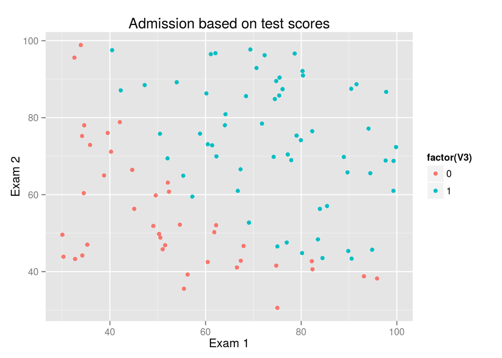

```r
library(ggplot2)
test_scores <- read.csv("./data/ex2data1.txt", header=FALSE)
p <- ggplot(test_scores, aes(x=V1, y=V2, colour=factor(V3))) + geom_point() +
  labs(title="Admission based on test scores") + ylab("Exam 2") + xlab("Exam 1")
p
```

## Implementation

The logistic regression hypothesis function is defined as $h_{\theta}(x) = g(\theta^{T}x)$

where $g$ is the sigmoid function, defined as $g(z) = \frac{1}{1 + e^{-z}}$

### Sigmoid function

```r
sigmoid_function <- function(z){
  sigmoid <- 1 / (1 +exp(-z))
  return(sigmoid)
}

# Evaluating sigmoid(0) should give you exactly 0.5
sigmoid_function(0)
```

```
## [1] 0.5
```

### Cost function and gradient

Recall that the cost function in logistic regression is $J(\theta) = \frac{1}{m} \sum_{i=1}^{m}[-y^{(i)}log(h_{\theta}(x^{(i)})) - (1 - y^{(i)})log(1-h_{\theta}(x^{(i)}))]$

and the gradient for the cost is a vector of the same length as $\theta$ where the j<sup>th</sup> element (for j=0,1,…,n) is defined as follows: $\frac{\partial J(\theta)}{\partial \theta_{j}} = \frac{1}{m} \sum_{i=1}^{m}(h_{\theta}(x^{(i)}) - y^{(i)})x^{(i)}_{j}$

```r
# Cost function
cost_function <- function(X, y, theta){
  hx <- sigmoid_function( X %*% theta)
  m <- dim(X)[1]
  J <- (1/m) * sum(-y * log(hx) - (1-y)*log(1 - hx))
  return(J)
}
```

Test the `cost_function` implementation. Using $\theta$ values of [0, 0, 0], the `cost_function` if implemented correctly should return 0.693

```r
# Test the cost function implementation
X <- as.matrix(test_scores[,-3])
X <- cbind(rep(1, dim(X)[1]), X)
m <- dim(X)[1]
n <- dim(X)[2]
y <- as.matrix(test_scores[,3])
theta <- matrix(0, nrow=n, ncol=1)

cost_function(X, y, theta)
```

```
## [1] 0.6931472
```

### Optimization with Gradient Descent

We will use gradient descent to find $\theta$ parameters that optimized $J(\theta)$

```r
# Gradient descent algorithm
gradient_descent <- function(X, y, theta, iters=1e4, alpha=0.0001){
  J <- rep(NA, iters)
  for(i in 1:iters){
    hx <- sigmoid_function( X %*% theta)
    theta <- theta - alpha * (1/m) * t(t(hx - y) %*% X)
    J[i] <- cost_function(X, y, theta)
  }
  return(list(cost_hist=J, params=theta))
}
```

Now lets test the optimization using gradient descent. For this dataset, if the cost function converges completely you should see a total cost of about 0.203.

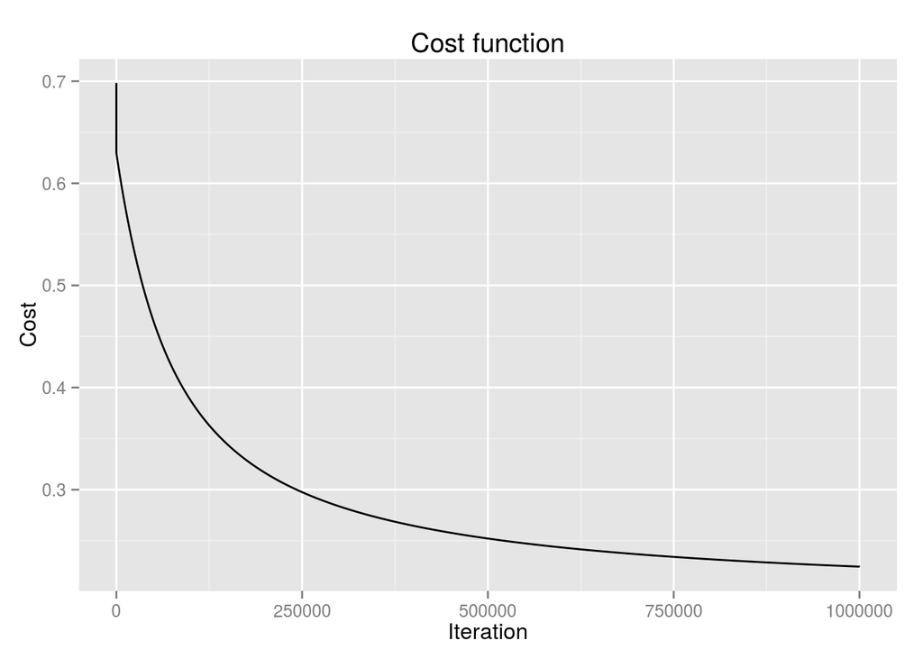

```r
fit <- gradient_descent(X, y, theta, alpha=0.001, iters=1e6)
qplot(1:length(fit$cost_hist), fit$cost_hist, geom="line", main="Cost function", ylab="Cost", xlab="Iteration")
```

From the plot above, we see that the function does not converge completely, however we do see that there appears to be a lower limit somewhere around 0.2 as expected. Our learned parameters that minimze the cost function are returned in the `fit` object and are found to be -15.3951787, 0.1282599, 0.1224793.

### Plot decision boundary

Now that we have learned the $\theta$ parameters that minimize the cost function $J(\theta)$ we can use them to make predictions given two exam scores. Also, we can now use the $\theta$ parameters to observe the decision boundary by making admission predictions for every possible test score combination. Below, we loop through every possible test score and make a prediction, we can then plot the points for each test score and color code them using the results from our prediction.

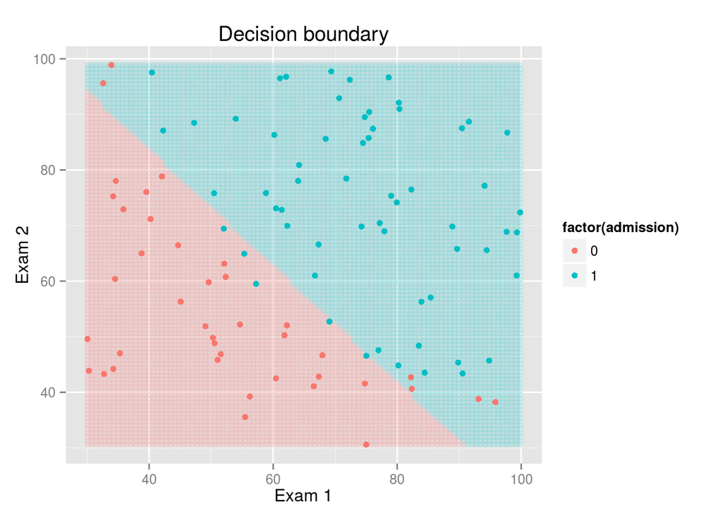

```r
data_max <- apply(X[,-1], 2, max)
data_min <- apply(X[,-1], 2, min)
decision_boundary <- data.frame(x=NA, y=NA, admission=NA)
count <- 1
for(i in seq(from=data_min[1], to=data_max[1], length.out=100)){
  for(j in seq(from=data_min[2], to=data_max[2], length.out=100)){
    data_row <- c(i, j, round(sigmoid_function(c(1,i,j) %*% fit$params)))
    decision_boundary[count, ] <- data_row
    count <- count + 1
  }
}
p <- ggplot(decision_boundary) + geom_point(aes(x=x, y=y,colour=factor(admission)), alpha=0.15) +
  geom_point(data = test_scores, aes(x=V1, y=V2, colour=factor(V3))) + labs(title="Decision boundary") +
  ylab("Exam 2") + xlab("Exam 1")

p
```

We can see that decision boundary appropriately separates the admitted students from the non-admittted students.

### Logistic regression using R-base

```r
# Logistic regression using GLM
fit2 <- glm(V3 ~ V1 + V2, data = test_scores, family = "binomial")
coef(fit2)
```

```
## (Intercept)          V1          V2
## -25.1613335   0.2062317   0.2014716
```

```r
# Logistic regression using self-implemented gradient descent
fit$params
```

```
##           [,1]
##    -15.3951787
## V1   0.1282599
## V2   0.1224793
```